# Template for Final Notebook

*Version:* `1.2` *(Jupytext, time measurements, logger, param notebook execution, fixes)*

# Table of Content

- Notebook Description
- General Settings
  - Paths
  - Notebook Functionality and Appearance
  - External Libraries
  - Internal Code
  - Constants
- Analysis
  - Questions
    - Q1 Run Mage
    - Q2 Creating a project
    - Q3 Creating a pipeline
    - Q4 Data preparation
    - Q5 Train a model
    - Q6 Register the model
- Final Timestamp

# Notebook Description

ToC

# GENERAL SETTINGS

ToC  
General settings for the notebook (paths, python libraries, own code, notebook constants).

> *NOTE: All imports and constants for the notebook settings shoud be here. Nothing should be imported in the analysis section.*

### Paths

ToC

Adding paths that are necessary to import code from within the repository.

```python
import sys
import os
sys.path+=[os.path.join(os.getcwd(), ".."), os.path.join(os.getcwd(), "../..")] # one and two up
```

### Notebook Functionality and Appearance

ToC  
Necessary libraries for notebook functionality:

- A button for hiding/showing the code. By default it is deactivated and can be activated by setting CREATE_BUTTON constant to True.

> **NOTE: This way, using the function, the button works only in active notebook. If the functionality needs to be preserved in html export, then the code has to be incluced directly into notebook.**
- Set notebook width to 100%.
- Notebook data frame setting for better visibility.
- Initial timestamp setting and logging the start of the execution.

#### Overall Setting Specification

```python
LOGGER_CONFIG_NAME = "logger_file_limit_console"
ADDAPT_WIDTH = True
```

#### Overall Behaviour Setting

```python
try:
    from src.utils.notebook_support_functions import create_button, get_notebook_name
    NOTEBOOK_NAME = get_notebook_name()
    SUPPORT_FUNCTIONS_READ = True
except:
    NOTEBOOK_NAME = "NO_NAME"
    SUPPORT_FUNCTIONS_READ = False
```

```python
from src.utils.logger import Logger
from src.utils.envs import Envs
from src.utils.config import Config
from pandas import options
from IPython.display import display, HTML
```

```python
options.display.max_rows = 500
options.display.max_columns = 500
envs = Envs()
envs.set_logger(LOGGER_CONFIG_NAME)
Logger().start_timer(f"NOTEBOOK; Notebook name: {NOTEBOOK_NAME}")
if ADDAPT_WIDTH:
    display(HTML("<style>.container { width:100% !important; }</style>")) # notebook width
```

```
2024-06-02 18:14:45,068 - file_limit_console - INFO - Logger was created on WS-3000 in branche 003_do_week_03_hw.
2024-06-02 18:14:45,070 - file_limit_console - INFO - Process: NOTEBOOK; Notebook name: W03_HW.ipynb; Timer started;
```

```python
# create_button()
```

### External Libraries

ToC

```python
from datetime import datetime

from IPython.display import display, HTML, Image
```

### Internal Code

ToC  
Code, libraries, classes, functions from within the repository.

```python
from src.utils.date_time_functions import create_datetime_id
```

### Constants

ToC  
Constants for the notebook.

> *NOTE: Please use all letters upper.*

#### General Constants

ToC

```python
# from src.global_constants import *  # Remember to import only the constants in use
N_ROWS_TO_DISPLAY = 2
FIGURE_SIZE_SETTING = {"autosize": False, "width": 2200, "height": 750}
DATA_PROCESSING_CONFIG_NAME = "data_processing_basic"
```

#### Constants for Setting Automatic Run

ToC

```python
# MANDATORY FOR CONFIG DEFINITION AND NOTEBOOK AND ITS OUTPUTS IDENTIFICATION #########################################
PYTHON_CONFIG_NAME = "python_local"
ID = create_datetime_id(now=datetime.now(), add_micro=False)
# (END) MANDATORY FOR CONFIG DEFINITION AND NOTEBOOK AND ITS OUTPUTS IDENTIFICATION ###################################
```

#### Python Config Initialisation

ToC

```python
envs.set_config(PYTHON_CONFIG_NAME)
```

#### Notebook Specific Constants

ToC

# ANALYSIS

ToC

## Questions

ToC

### Q1 Run Mage

ToC

First, let's run Mage with Docker Compose. Follow the quick start guideline.

What's the version of Mage we run?

(You can see it in the UI)

[figure not shown]

```python
display(Image(filename="W3_Q01.png"))
```

```python
answer = f"Run Version of Mage is: {'v0.9.70'}"
display(HTML(f"<p style='font-weight:bold; background-color:black; color:white; font-size:20px; padding:10px;'>Answer: {answer}</p>"))
```

Answer: Run Version of Mage is: v0.9.70

### Q2 Creating a project

ToC

Now let's create a new project. We can call it "homework_03", for example.

How many lines are in the created metadata.yaml file?

35  
45  
55  
65

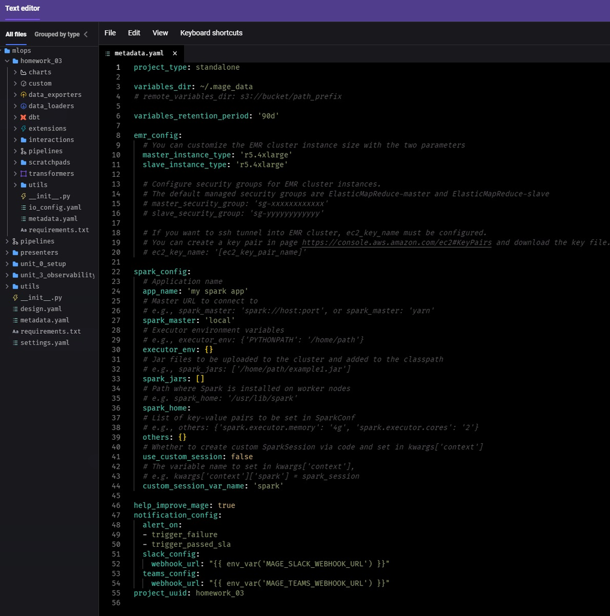

```python
display(Image(filename="W3_Q02.png"))
```

```python
answer = f"There are {55} lines of code in created metadata .yaml file"
display(HTML(f"<p style='font-weight:bold; background-color:black; color:white; font-size:20px; padding:10px;'>Answer: {answer}</p>"))
```

Answer: There are 55 lines of code in created metadata .yaml file

### Q3 Creating a pipeline

ToC

Let's create an ingestion code block.

In this block, we will read the March 2023 Yellow taxi trips data.

How many records did we load?

3,003,766  
3,203,766  
3,403,766  
3,603,766

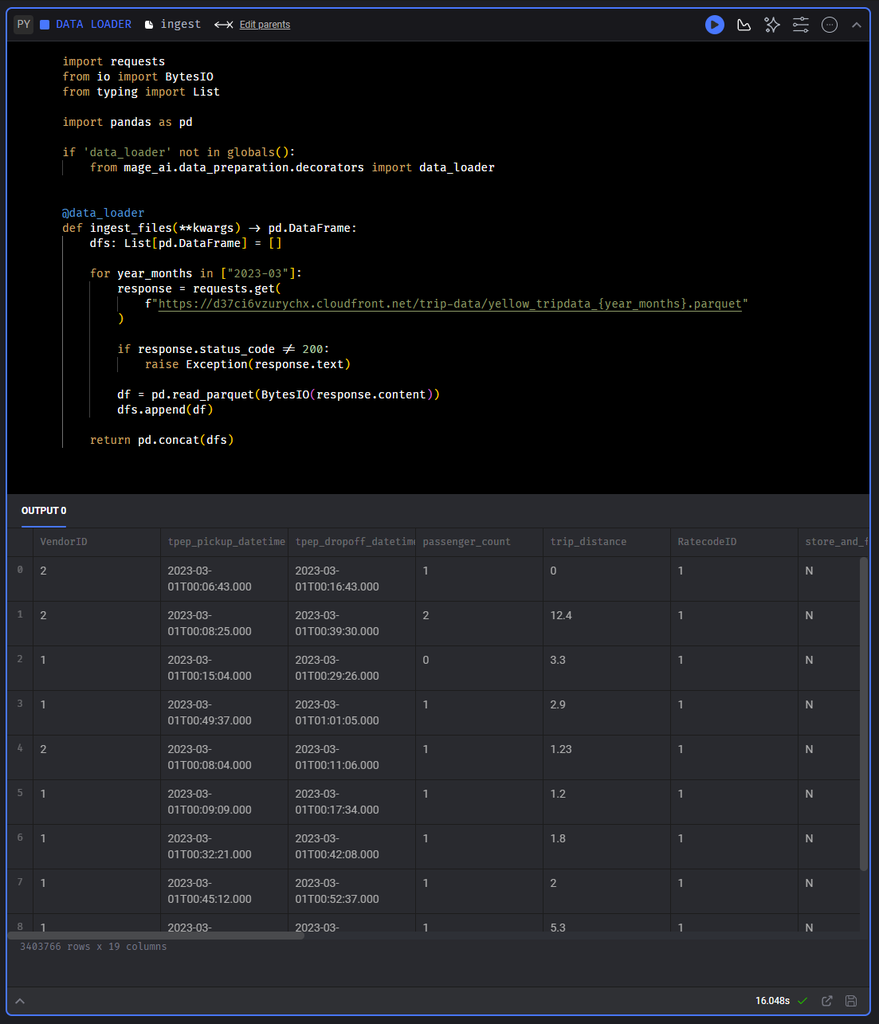

```python
display(Image(filename="W3_Q03.png"))
```

```python
answer = f"There are {3,403,766} records in the data read."
display(HTML(f"<p style='font-weight:bold; background-color:black; color:white; font-size:20px; padding:10px;'>Answer: {answer}</p>"))
```

Answer: There are (3, 403, 766) records in the data read.

### Q4 Data preparation

ToC

Let's use the same logic for preparing the data we used previously. We will need to create a tranformer code block and put this code there.

This is what we used (adjusted for yellow dataset):

```
def read_dataframe(filename):
    df = pd.read_parquet(filename)

    df['duration'] = df.tpep_dropoff_datetime - df.tpep_pickup_datetime
    df.duration = df.duration.dt.total_seconds() / 60

    df = df[(df.duration >= 1) & (df.duration <= 60)]

    categorical = ['PULocationID', 'DOLocationID']
    df[categorical] = df[categorical].astype(str)

    return df
Let's adjust it and apply to the data we loaded in question 3.
```

What's the size of the result?

2,903,766  
3,103,766  
3,316,216  
3,503,766

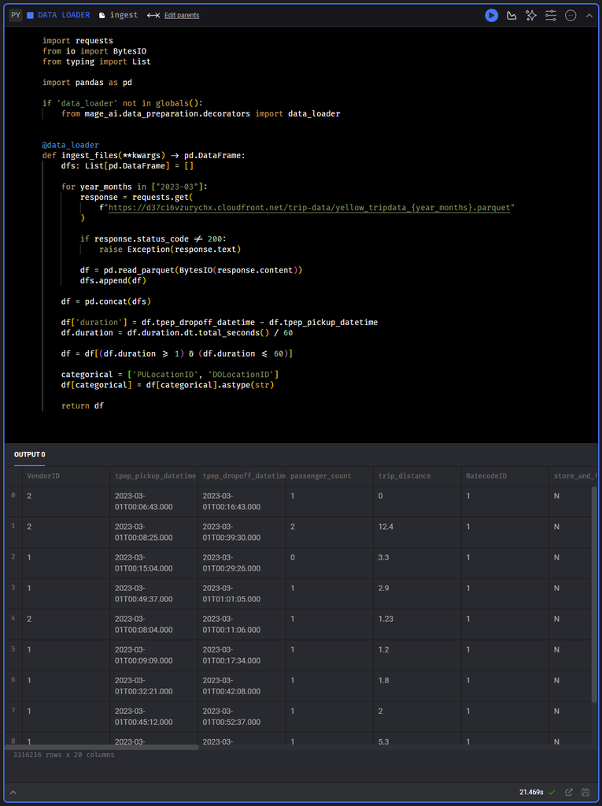

```python
display(Image(filename="W3_Q04.png"))
```

```python
answer = f"There are {3,316,216} records in the data read."
display(HTML(f"<p style='font-weight:bold; background-color:black; color:white; font-size:20px; padding:10px;'>Answer: {answer}</p>"))
```

Answer: There are (3, 316, 216) records in the data read.

### Q5 Train a model

ToC

We will now train a linear regression model using the same code as in homework 1

Fit a dict vectorizer Train a linear regression with default parameres Use pick up and drop off locations separately, don't create a combination feature Let's now use it in the pipeline. We will need to create another tranformation block, and return both the dict vectorizer and the model

What's the intercept of the model?

Hint: print the intercept_ field in the code block

21.77  
24.77  
27.77  
31.77

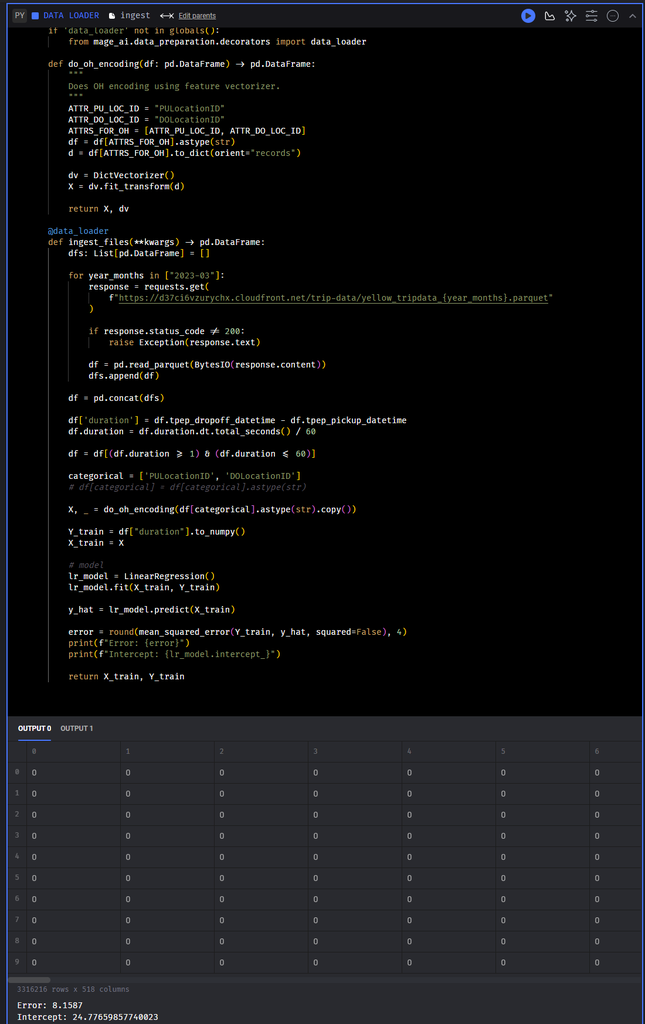

```python
display(Image(filename="W3_Q05.png"))
```

```python
answer = f"The intercept is: {24.77}."
display(HTML(f"<p style='font-weight:bold; background-color:black; color:white; font-size:20px; padding:10px;'>Answer: {answer}</p>"))
```

Answer: The intercept is: 24.77.

### Q6 Register the model

ToC

The model is traned, so let's save it with MLFlow.

If you run mage with docker-compose, stop it with Ctrl+C or

```
docker-compose down
```

Let's create a dockerfile for mlflow, e.g. mlflow.dockerfile:

```
FROM python:3.10-slim

RUN pip install mlflow==2.12.1

EXPOSE 5000

CMD [ \
    "mlflow", "server", \
    "--backend-store-uri", "sqlite:///home/mlflow/mlflow.db", \
    "--host", "0.0.0.0", \
    "--port", "5000" \
]
```

And add it to the docker-compose.yaml:

```
  mlflow:
    build:
      context: .
      dockerfile: mlflow.dockerfile
    ports:
      - "5000:5000"
    volumes:
      - "${PWD}/mlflow:/home/mlflow/"
    networks:
      - app-network
```

Note that app-network is the same network as for mage and postgre containers. If you use a different compose file, adjust it.

We should already have mlflow==2.12.1 in requirements.txt in the mage project we created for the module. If you're starting from scratch, add it to your requirements.

Next, start the compose again and create a data exporter block.

In the block, we

Log the model (linear regression) Save and log the artifact (dict vectorizer) If you used the suggested docker-compose snippet, mlflow should be accessible at http://mlflow:5000.

# Final Timestamp

ToC

```python
Logger().end_timer()
```

```
2024-06-02 18:14:45,339 - file_limit_console - INFO - Process: NOTEBOOK; Notebook name: W03_HW.ipynb; Timer ended; Process Duration [s]: 0.27; Process Duration [m]: 0.0
```